# Data Analytics for Finance

BM17FI · Rotterdam School of Management

ASSIGNMENT 06

## Learning Objectives

This assignment prepares you for MSc thesis Module 2/3 (replication and extension) by having you:

1. Read and understand methodology from a published empirical finance paper
2. Build an analysis panel from multiple raw data sources (merge, reshape)
3. Calculate returns following published methodology (compound, standardized)
4. Create derived variables (terciles, interactions)
5. Work with panel data at geographic (municipality) level
6. Estimate fixed effects regressions with appropriate standard errors
7. Interpret results and discuss limitations honestly
8. Understand the gap between "ideal" identification and feasible tests

📝 Assignment Tasks

In this assignment, you will:

1. Load and examine three raw datasets (crime, income, stock returns)
2. Calculate monthly stock returns following published methodology
3. Reshape crime data from long to wide format
4. Merge datasets to create a municipality-month panel
5. Create analysis variables (income terciles, interactions)
6. Estimate panel regressions testing differential effects
7. Interpret findings and discuss limitations
8. Reflect on thesis Module 2/3 connection

# Setup

## Environment Setup

We begin by clearing the environment and preparing Stata for analysis.

```
✅ The environment is cleared and ready.
```

## Install Required Packages

This assignment requires several specialized packages:

- `reghdfe`: Fast fixed effects regression
- `ftools`: Tools for working with fixed effects
- `estout`: Export regression tables
- `rangestat`: Calculate rolling statistics (for trailing SD)

```
checking reghdfe consistency and verifying not already installed...
all files already exist and are up to date.
✅ reghdfe installed.
checking ftools consistency and verifying not already installed...
all files already exist and are up to date.
✅ ftools installed.
checking estout consistency and verifying not already installed...
all files already exist and are up to date.
✅ estout installed.
checking rangestat consistency and verifying not already installed...
all files already exist and are up to date.
✅ rangestat installed.
```

## Set File Paths

We define global macros for all file paths to keep code clean and portable.

```
/Users/casparm2/Local/GitHub/MSc_finance/private/assignments/06-assignment
📁 Base directory: /Users/casparm2/Local/GitHub/MSc_finance/private/assignments/06-assignment
📁 Raw data folder: /Users/casparm2/Local/GitHub/MSc_finance/private/assignments/06-assignment/data/raw
📁 Processed data folder: /Users/casparm2/Local/GitHub/MSc_finance/private/assignments/06-assignment/data/processed
📁 Output directory: /Users/casparm2/Local/GitHub/MSc_finance/private/assignments/06-assignment/output
📁 Tables folder: /Users/casparm2/Local/GitHub/MSc_finance/private/assignments/06-assignment/output/tables
📁 Figures folder: /Users/casparm2/Local/GitHub/MSc_finance/private/assignments/06-assignment/output/figures
```

# Part A: Data Preparation

## Section 1: Introduction and Paper Context

### Research Question

This assignment is based on **Huck (2024)** "The Psychological Externalities of Investing: Evidence from Stock Returns and Crime" published in *The Review of Financial Studies*.

**Key finding from Huck (2024)**:

- When stock markets rise, violent crime **decreases** in high-income areas (where people are more likely to be investors)
- When stock markets rise, violent crime **increases** in low-income areas (where people are less likely to be investors)
- This suggests that relative wealth/status affects psychological well-being and behavior

### What We're Testing

We test whether this differential relationship holds in the Netherlands using:

Published research often starts with an observation in one setting. A valuable contribution is testing whether findings generalize to new contexts. Even null results are informative.

**In your thesis, you will spend 60-80% of your time preparing data.** This assignment gives you practice with the exact operations you'll need:

- Merging datasets from different sources
- Calculating returns properly (following published methodology)
- Reshaping data
- Creating analysis variables

### Assignment Roadmap

**Part A: Data Preparation** (Sections 1-6)

1. Load raw data (crime, income, AEX prices)
2. Calculate monthly returns (compound and standardized)
3. Reshape crime data (long → wide)
4. Merge datasets into a municipality-month panel
5. Create analysis variables (terciles, interactions)

**Part C: Reflection** (Sections 15-16) — *Not included in this submission*

ℹ️ Why Return Calculation Matters

Huck (2024) uses **standardized returns**: daily returns divided by trailing 252-day standard deviation. This follows Engelberg & Parsons (2016) and Edmans, Garcia & Norli (2007).

Standardization matters because a 2% return during low volatility is more "newsworthy" than 2% during a crisis. A standardized return of 2 means the market moved 2 standard deviations—regardless of the volatility regime.

For monthly analysis, we aggregate standardized daily returns. This preserves the "surprise" interpretation while matching our crime data frequency.

⚠️ Important Limitation

The original paper uses **daily** data to identify contemporaneous same-day effects. Our **monthly** data cannot test this timing mechanism.

We are testing a weaker hypothesis: whether monthly returns correlate with monthly crime differently across income groups.

This is a common constraint in replication work—data availability often limits what can be tested. Your thesis will face similar challenges.

## Section 2: Load and Examine Raw Data

We have three raw datasets to work with:

1. **crime.dta**: Monthly crime counts by municipality (long format by crime type)
2. **income_data.dta**: Average median income by municipality (cross-section)
3. **aex_daily.dta**: Daily AEX index prices (we'll compute returns)

Let's load and examine each dataset to understand its structure.

### Task 2.1: Load and Examine Crime Data

📝 Task

Load the crime dataset from `$raw/crime.dta` and examine its structure. The data should contain monthly crime counts for each municipality and crime type. Use `describe` to see variables, `list` to see the first few observations, and `summarize` to get basic statistics.

[figure not shown]

Stata Tip

Consider using the following commands:

- `use "$raw/crime.dta", clear` — to load the dataset
- `describe` — to see variable names and types
- `list in 1/10` — to view first 10 rows
- `tab crime_type` — to see what crime types are included
- `summarize reported_crimes` — to get basic statistics

```
Contains data from /Users/casparm2/Local/GitHub/MSc_finance/private/assignments/06-assignment/data/raw/crime.dta
 Observations:       172,344
    Variables:             5                  06 Jan 2026 22:55
------------------------------------------------------------------------------------------------------------------------
Variable      Storage   Display    Value
    name         type    format    label      Variable label
------------------------------------------------------------------------------------------------------------------------
crime_type      str21   %-9s                  Type of Crime
municipality~de str6    %-9s                  Municipality Code
municipality~me str29   %-9s                  Municipality Name
reported_crimes long    %12.0g
date            double  %td                   Date (Year-Month)
------------------------------------------------------------------------------------------------------------------------
Sorted by:

     +-------------------------------------------------------------------+
     | crime_type          munic~de   municipa~me   report~s        date |
     |-------------------------------------------------------------------|
  1. | Totaal misdrijven   GM1680     Aa en Hunze         84   01jan2012 |
  2. | Totaal misdrijven   GM1680     Aa en Hunze        103   01feb2012 |
  3. | Totaal misdrijven   GM1680     Aa en Hunze        101   01mar2012 |
  4. | Totaal misdrijven   GM1680     Aa en Hunze         71   01apr2012 |
  5. | Totaal misdrijven   GM1680     Aa en Hunze         78   01may2012 |
     |-------------------------------------------------------------------|
  6. | Totaal misdrijven   GM1680     Aa en Hunze         50   01jun2012 |
  7. | Totaal misdrijven   GM1680     Aa en Hunze         69   01jul2012 |
  8. | Totaal misdrijven   GM1680     Aa en Hunze         99   01aug2012 |
  9. | Totaal misdrijven   GM1680     Aa en Hunze         73   01sep2012 |
 10. | Totaal misdrijven   GM1680     Aa en Hunze         77   01oct2012 |
     +-------------------------------------------------------------------+

        Type of Crime |      Freq.     Percent        Cum.
----------------------+-----------------------------------
1.4.2 Moord, doodslag |     57,448       33.33       33.33
   1.4.5 Mishandeling |     57,448       33.33       66.67
    Totaal misdrijven |     57,448       33.33      100.00
----------------------+-----------------------------------
                Total |    172,344      100.00

    Variable |        Obs        Mean    Std. dev.       Min        Max
-------------+---------------------------------------------------------
reported_c~s |    126,324    101.4997     377.645          1       9239
---- CHECKPOINT: Crime data loaded ----
Observations: 172344
Variables: 5
```

```
✅ Crime data loaded successfully.
```

### Task 2.2: Load and Examine Income Data

📝 Task

Load the income dataset from `$raw/income_data.dta` and examine its structure. This is a cross-sectional dataset with one observation per municipality containing average median standardized income for 2011-2018.

```
Contains data from /Users/casparm2/Local/GitHub/MSc_finance/private/assignments/06-assignment/data/raw/income_data.dta
 Observations:           355
    Variables:             2                  06 Jan 2026 22:55
------------------------------------------------------------------------------------------------------------------------
Variable      Storage   Display    Value
    name         type    format    label      Variable label
------------------------------------------------------------------------------------------------------------------------
municipality_~e str6    %-9s                  Municipality Code
avg_median_st~e double  %10.0g                Average Median Standardized Income
------------------------------------------------------------------------------------------------------------------------
Sorted by:

     +----------------------+
     | munici~e   avg_med~e |
     |----------------------|
  1. | GM0003     20.606186 |
  2. | GM0010     21.084211 |
  3. | GM0014     19.855506 |
  4. | GM0024     22.255462 |
  5. | GM0034     22.317833 |
     |----------------------|
  6. | GM0037     20.437981 |
  7. | GM0047      20.88774 |
  8. | GM0050     23.638929 |
  9. | GM0059     20.745074 |
 10. | GM0060     23.382847 |
     +----------------------+

    Variable |        Obs        Mean    Std. dev.       Min        Max
-------------+---------------------------------------------------------
avg_median~e |        355    23.53126    1.867351   19.83227   36.45822
---- CHECKPOINT: Income data loaded ----
Municipalities: 355
```

```
✅ Income data loaded successfully.
```

### Task 2.3: Load and Examine AEX Daily Price Data

📝 Task

Load the daily AEX index data from `$raw/aex_daily.dta` and examine its structure. This dataset contains daily closing prices for the AEX index. We will calculate returns from these prices in the next section.

```
Contains data from /Users/casparm2/Local/GitHub/MSc_finance/private/assignments/06-assignment/data/raw/aex_daily_data.dt
> a
 Observations:         2,609
    Variables:             2                  06 Jan 2026 22:55
------------------------------------------------------------------------------------------------------------------------
Variable      Storage   Display    Value
    name         type    format    label      Variable label
------------------------------------------------------------------------------------------------------------------------
date            double  %td                   Date
price           double  %10.0g                AEX Index Closing Price
------------------------------------------------------------------------------------------------------------------------
Sorted by:

     +----------------------+
     |      date      price |
     |----------------------|
  1. | 03jan2011   359.8629 |
  2. | 04jan2011   358.8617 |
  3. | 05jan2011   357.2818 |
  4. | 06jan2011   356.8858 |
  5. | 07jan2011   356.4425 |
     |----------------------|
  6. | 10jan2011   354.2092 |
  7. | 11jan2011    358.303 |
  8. | 12jan2011   362.4137 |
  9. | 13jan2011   360.7873 |
 10. | 14jan2011   361.3202 |
     +----------------------+

    Variable |        Obs        Mean    Std. dev.       Min        Max
-------------+---------------------------------------------------------
       price |      2,609    451.2762    92.43622   263.4371   629.2317

    Variable |        Obs        Mean    Std. dev.       Min        Max
-------------+---------------------------------------------------------
        date |      2,609     20454.8    1054.616      18630      22280
---- CHECKPOINT: AEX data loaded ----
Trading days: 2609
```

```
✅ AEX data loaded successfully.
```

## Section 3: Calculate AEX Returns (Following Huck 2024 Methodology)

Following Huck (2024), we need to calculate **standardized returns**. This involves:

1. Calculate daily returns
2. Calculate trailing 252-day standard deviation (one trading year)
3. Standardize daily returns by dividing by trailing SD
4. Aggregate to monthly frequency

We'll also calculate compound monthly returns for comparison.

### Task 3.1: Calculate Daily Returns

📝 Task

Calculate daily returns from the AEX price data. Create both:

- **Simple returns**: ret_daily = (price<sub>t</sub> / price<sub>t-1</sub>) - 1
- **Log returns**: ret_log = ln(price<sub>t</sub> / price<sub>t-1</sub>)

Make sure the data is sorted by date first.

[figure not shown]

Stata Tip

For time series operations:

- `sort date` — sort data chronologically
- `gen ret_daily = (price / price[_n-1]) - 1` — simple return
- `gen ret_log = ln(price / price[_n-1])` — log return
- `summarize ret_daily, detail` — check for reasonable range

```
(1 missing value generated)
(1 missing value generated)

                     Daily simple return
-------------------------------------------------------------
      Percentiles      Smallest
 1%    -.0323815      -.1075333
 5%    -.0172826      -.0764755
10%    -.0116792        -.05704       Obs               2,608
25%    -.0047384       -.052363       Sum of wgt.       2,608

50%     .0004368                      Mean           .0002727
                        Largest       Std. dev.      .0110496
75%     .0058393       .0421586
90%     .0118066       .0452309       Variance       .0001221
95%     .0171069       .0461471       Skewness      -.5256861
99%     .0295844       .0897213       Kurtosis       10.82545
---- CHECKPOINT: Daily returns calculated ----
Non-missing returns: 2608
Mean daily return: 0.0003
Std dev: 0.0110
```

```
✅ Daily returns calculated and in reasonable range.
```

### Task 3.2: Calculate Trailing 252-Day Standard Deviation

📝 Task

Calculate the trailing 252-day (approximately one trading year) standard deviation of daily returns. This will be used to standardize returns. Use the `rangestat` package to calculate rolling statistics efficiently.

[figure not shown]

Stata Tip

The `rangestat` command calculates statistics over a moving window:

```
               Trailing 252-day SD of returns
-------------------------------------------------------------
      Percentiles      Smallest
 1%     .0052468       .0011458
 5%     .0058144       .0015453
10%     .0067857       .0016472       Obs               2,606
25%     .0075677       .0021919       Sum of wgt.       2,606

50%     .0084327                      Mean           .0102832
                        Largest       Std. dev.      .0038261
75%     .0130778       .0203429
90%     .0162531       .0203489       Variance       .0000146
95%     .0187518       .0203502       Skewness       .9560908
99%      .020195       .0203506       Kurtosis       2.984837
  3
---- CHECKPOINT: Trailing SD calculated ----
Missing SD values (first ~252 days): 3
Mean trailing SD: 0.0103
```

```
✅ Trailing 252-day standard deviation calculated.
```

### Task 3.3: Calculate Standardized Daily Returns

📝 Task

Create standardized daily returns by dividing each day's return by its trailing standard deviation. This follows the Huck (2024) methodology and creates a measure of "surprise" that accounts for the volatility regime.

```
(3 missing values generated)

             Standardized daily return (ret/SD)
-------------------------------------------------------------
      Percentiles      Smallest
 1%    -3.347214      -9.463235
 5%    -1.738406      -7.754665
10%    -1.204699      -5.648883       Obs               2,606
25%    -.5011903       -4.94842       Sum of wgt.       2,606

50%      .039744                      Mean           .0189555
                        Largest       Std. dev.      1.077812
75%     .6185057       3.729102
90%     1.172071       4.049637       Variance       1.161679
95%     1.639769        5.27277       Skewness      -.7527249
99%      2.53291       5.910226       Kurtosis       8.611722
---- CHECKPOINT: Standardized returns calculated ----
Non-missing standardized returns: 2606
Mean: 0.0190
Std dev: 1.0778
```

```
✅ Standardized daily returns calculated.
```

### Task 3.4: Create Year-Month Variable

📝 Task

Create a year-month variable that we'll use to aggregate daily data to monthly frequency. Use Stata's `mofd()` function to convert daily dates to monthly format.

[figure not shown]

Stata Tip

To work with monthly dates:

- `gen year_month = mofd(date)` — convert daily date to monthly
- `format year_month %tm` — format as YYYY-MM

```
---- CHECKPOINT: Year-month variable created ----
Unique months: 120
```

```
✅ Year-month variable created.
```

### Task 3.5: Aggregate to Monthly Frequency

📝 Task

Aggregate daily data to monthly frequency. Calculate:

- **Compound return**: exp(sum of log returns) - 1
- **Standardized monthly return**: sum of standardized daily returns
- **Volatility**: standard deviation of daily returns
- **Trading days**: count of observations per month

[figure not shown]

Stata Tip

First create monthly aggregates within groups, then collapse:

- `bysort year_month: egen ret_log_sum = total(ret_log)`
- `gen ret_compound = exp(ret_log_sum) - 1`
- `bysort year_month: egen ret_std_monthly = total(ret_std_daily)`
- `collapse (first) ret_compound ret_std_monthly (sd) volatility = ret_daily (count) n_trading_days = ret_daily, by(year_month)`

```
     +--------------------------------------------------------------------+
     | year_m~h   ret_com~d   ret_std~y   volati~y   n_trad~s        date |
     |--------------------------------------------------------------------|
  1. |   2011m1    .0024548    .5534533    .007666         20   01jan2011 |
  2. |   2011m2    .0232263    2.948537   .0068946         20   01feb2011 |
  3. |   2011m3   -.0094981   -2.251385   .0097187         23   01mar2011 |
  4. |   2011m4   -.0155369   -1.979866   .0076843         21   01apr2011 |
  5. |   2011m5   -.0291778   -3.587304   .0083145         22   01may2011 |
     |--------------------------------------------------------------------|
  6. |   2011m6    -.028016   -3.423634   .0093389         22   01jun2011 |
  7. |   2011m7   -.0308594   -3.683877    .010141         21   01jul2011 |
  8. |   2011m8   -.1100779   -13.34819   .0223073         23   01aug2011 |
  9. |   2011m9   -.0435389   -3.706579    .023562         22   01sep2011 |
 10. |  2011m10    .0975143    6.884334   .0174383         21   01oct2011 |
     |--------------------------------------------------------------------|
 11. |  2011m11   -.0254433   -1.531934   .0208009         22   01nov2011 |
 12. |  2011m12    .0427059    2.665466   .0124832         22   01dec2011 |
     +--------------------------------------------------------------------+

    Variable |        Obs        Mean    Std. dev.       Min        Max
-------------+---------------------------------------------------------
  year_month |        120       671.5    34.78505        612        731
ret_compound |        120    .0054344    .0408573  -.1100779   .1351352
ret_std_mo~y |        120    .4116507    4.289544  -13.34819    8.55268
  volatility |        120    .0098128    .0052895    .003573   .0422672
n_trading_~s |        120    21.73333    .9850422         20         23
-------------+---------------------------------------------------------
        date |        120    20438.45    1058.793      18628      22250
---- CHECKPOINT: Monthly aggregation complete ----
Months: 120
Mean monthly return: 0.0054
SD of monthly returns: 0.0409
```

```
✅ Monthly returns calculated successfully.
```

### Task 3.6: Save Monthly Returns Data

📝 Task

Save the monthly returns data to `$processed/aex_monthly.dta`. This will be merged with the crime data later.

```
(file /Users/casparm2/Local/GitHub/MSc_finance/private/assignments/06-assignment/data/processed/aex_monthly.dta not
    found)
file /Users/casparm2/Local/GitHub/MSc_finance/private/assignments/06-assignment/data/processed/aex_monthly.dta saved
✅ Monthly returns saved to: /Users/casparm2/Local/GitHub/MSc_finance/private/assignments/06-assignment/data/processed/ae
> x_monthly.dta
Observations: 120
```

```
✅ Monthly returns file saved successfully.
```

## Section 4: Reshape Crime Data (Long to Wide)

The crime data is currently in **long format**: one row per municipality × month × crime_type combination.

We need **wide format**: one row per municipality × month, with separate columns for each crime type.

**Why?** For regression analysis, we need a single outcome variable per observation.

⚠️ Important: Reshape Syntax

Stata's `reshape` command requires:

1. **Unique i() identifier** — here: municipality_code date
2. **j() variable** with values to become column suffixes — here: crime_id (numeric)
3. **Variables to reshape** — here: reported_crimes

Common errors:

- Duplicates in i() j() combinations → check with: `duplicates report municipality_code date crime_id`
- String j() variable → must be numeric (that's why we create crime_id)

### Task 4.1: Examine Current Structure

📝 Task

Load the crime data and examine its current long format structure. Use `tab crime_type` to see what crime types are included.

```
Contains data from /Users/casparm2/Local/GitHub/MSc_finance/private/assignments/06-assignment/data/raw/crime.dta
 Observations:       172,344
    Variables:             5                  06 Jan 2026 22:55
------------------------------------------------------------------------------------------------------------------------
Variable      Storage   Display    Value
    name         type    format    label      Variable label
------------------------------------------------------------------------------------------------------------------------
crime_type      str21   %-9s                  Type of Crime
municipality~de str6    %-9s                  Municipality Code
municipality~me str29   %-9s                  Municipality Name
reported_crimes long    %12.0g
date            double  %td                   Date (Year-Month)
------------------------------------------------------------------------------------------------------------------------
Sorted by:

        Type of Crime |      Freq.     Percent        Cum.
----------------------+-----------------------------------
1.4.2 Moord, doodslag |     57,448       33.33       33.33
   1.4.5 Mishandeling |     57,448       33.33       66.67
    Totaal misdrijven |     57,448       33.33      100.00
----------------------+-----------------------------------
                Total |    172,344      100.00

     +--------------------------------------------------------+
     | municipa~me        date   crime_type          report~s |
     |--------------------------------------------------------|
  1. | Aa en Hunze   01jan2012   Totaal misdrijven         84 |
  2. | Aa en Hunze   01feb2012   Totaal misdrijven        103 |
  3. | Aa en Hunze   01mar2012   Totaal misdrijven        101 |
  4. | Aa en Hunze   01apr2012   Totaal misdrijven         71 |
  5. | Aa en Hunze   01may2012   Totaal misdrijven         78 |
     |--------------------------------------------------------|
  6. | Aa en Hunze   01jun2012   Totaal misdrijven         50 |
  7. | Aa en Hunze   01jul2012   Totaal misdrijven         69 |
  8. | Aa en Hunze   01aug2012   Totaal misdrijven         99 |
  9. | Aa en Hunze   01sep2012   Totaal misdrijven         73 |
 10. | Aa en Hunze   01oct2012   Totaal misdrijven         77 |
     |--------------------------------------------------------|
 11. | Aa en Hunze   01nov2012   Totaal misdrijven         67 |
 12. | Aa en Hunze   01dec2012   Totaal misdrijven         53 |
 13. | Aa en Hunze   01jan2013   Totaal misdrijven         76 |
 14. | Aa en Hunze   01feb2013   Totaal misdrijven         65 |
 15. | Aa en Hunze   01mar2013   Totaal misdrijven         56 |
     +--------------------------------------------------------+
---- CHECKPOINT: Crime data structure examined ----
Total observations (municipality × month × crime_type): 172344
Crime types: 3
```

```
✅ Crime data structure examined.
```

### Task 4.2: Create Numeric Crime Type Identifier

📝 Task

Create a numeric identifier for crime types because `reshape` requires numeric j() variable:

- 1 = "Totaal misdrijven" (Total crimes)
- 2 = "1.4.5 Mishandeling" (Assault)
- 3 = "1.4.2 Moord, doodslag" (Murder/manslaughter)

```
(172,344 missing values generated)
(57,448 real changes made)
(57,448 real changes made)
(57,448 real changes made)

           |          Type of Crime
  crime_id | 1.4.2 M..  1.4.5 M..  Totaal .. |     Total
-----------+---------------------------------+----------
     total |         0          0     57,448 |    57,448
   assault |         0     57,448          0 |    57,448
    murder |    57,448          0          0 |    57,448
-----------+---------------------------------+----------
     Total |    57,448     57,448     57,448 |   172,344
---- CHECKPOINT: Numeric crime_id created ----
```

```
✅ Numeric crime_id created.
```

### Task 4.3: Reshape Wide

📝 Task

Reshape the data from long to wide format, creating separate columns for each crime type. After reshaping, rename the variables to meaningful names (total_crimes, assault_crimes, murder_crimes).

[figure not shown]

Stata Tip

Reshaping steps:

- `keep municipality_code municipality_name date crime_id reported_crimes` — keep only needed variables
- `reshape wide reported_crimes, i(municipality_code date) j(crime_id)`
- `rename reported_crimes1 total_crimes` — rename to meaningful names

```
Duplicates in terms of municipality_code date crime_id

--------------------------------------
   Copies | Observations       Surplus
----------+---------------------------
        1 |       172344             0
--------------------------------------
(j = 1 2 3)

Data                               Long   ->   Wide
-----------------------------------------------------------------------------
Number of observations          172,344   ->   57,448
Number of variables                   5   ->   6
j variable (3 values)          crime_id   ->   (dropped)
xij variables:
                        reported_crimes   ->   reported_crimes1 reported_crimes2 reported_crimes3
-----------------------------------------------------------------------------

Contains data
 Observations:        57,448
    Variables:             6
------------------------------------------------------------------------------------------------------------------------
Variable      Storage   Display    Value
    name         type    format    label      Variable label
------------------------------------------------------------------------------------------------------------------------
municipality~de str6    %-9s                  Municipality Code
date            double  %td                   Date (Year-Month)
total_crimes    long    %12.0g                Total crimes reported
assault_crimes  long    %12.0g                Assault crimes reported
murder_crimes   long    %12.0g                Murder/manslaughter crimes reported
municipality~me str29   %-9s                  Municipality Name
------------------------------------------------------------------------------------------------------------------------
Sorted by: municipality_code  date
     Note: Dataset has changed since last saved.

     +------------------------------------------------------------------------------+
     | munic~de        date   total_~s   assaul~s   murder~s   municipality_name    |
     |------------------------------------------------------------------------------|
  1. | GM0014     01jan2012       1562        111          5   Groningen (gemeente) |
  2. | GM0014     01feb2012       1373         95          4   Groningen (gemeente) |
  3. | GM0014     01mar2012       1663        105          8   Groningen (gemeente) |
  4. | GM0014     01apr2012       1520         91          3   Groningen (gemeente) |
  5. | GM0014     01may2012       1728         90          3   Groningen (gemeente) |
     |------------------------------------------------------------------------------|
  6. | GM0014     01jun2012       1547         98          8   Groningen (gemeente) |
  7. | GM0014     01jul2012       1598         86          4   Groningen (gemeente) |
  8. | GM0014     01aug2012       1450         83          5   Groningen (gemeente) |
  9. | GM0014     01sep2012       1742        100          6   Groningen (gemeente) |
 10. | GM0014     01oct2012       1703        108          .   Groningen (gemeente) |
     +------------------------------------------------------------------------------+
---- CHECKPOINT: Data reshaped wide ----
Observations (municipality × month): 57448

    Variable |        Obs        Mean    Std. dev.       Min        Max
-------------+---------------------------------------------------------
total_crimes |     57,243    212.5807    539.8091          1       9239
assault_cr~s |     51,940    11.79105    28.66676          1        463
murder_cri~s |     17,141    2.372032    3.827666          1         48
```

```
✅ Data successfully reshaped to wide format.
```

### Task 4.4: Handle Missing Values

📝 Task

Check for and handle missing values in the crime count variables. Missing crime counts should be treated as zero (no crimes reported that month).

```
  205
Replacing 205 missing values in total_crimes with 0
(205 real changes made)
  5,508
Replacing 5508 missing values in assault_crimes with 0
(5,508 real changes made)
  40,307
Replacing 40307 missing values in murder_crimes with 0
(40,307 real changes made)

    Variable |        Obs        Mean    Std. dev.       Min        Max
-------------+---------------------------------------------------------
total_crimes |     57,448    211.8221    538.9942          0       9239
assault_cr~s |     57,448    10.66055    27.47804          0        463
murder_cri~s |     57,448    .7077531     2.35568          0         48
---- CHECKPOINT: Missing values handled ----
  0
Remaining missing values: 0
```

```
  0
  0
  0
✅ No missing crime values.
```

### Task 4.5: Save Wide Crime Data

📝 Task

Save the reshaped wide crime data to `$processed/crime_wide.dta`.

```
(file /Users/casparm2/Local/GitHub/MSc_finance/private/assignments/06-assignment/data/processed/crime_wide.dta not
    found)
file /Users/casparm2/Local/GitHub/MSc_finance/private/assignments/06-assignment/data/processed/crime_wide.dta saved
✅ Wide crime data saved to: /Users/casparm2/Local/GitHub/MSc_finance/private/assignments/06-assignment/data/processed/cr
> ime_wide.dta
Observations: 57448
```

```
✅ Wide crime data file saved successfully.
```

## Section 5: Merge Datasets

Now we merge our three datasets:

1. **Crime data** (wide format): municipality × month panel
2. **Income data**: municipality-level cross-section
3. **AEX returns**: monthly time series

The goal is to create a **municipality-month panel** with all variables.

### Task 5.1: Start with Crime Panel

📝 Task

Load the wide crime data to use as the base dataset for merging. This will be our "master" dataset since it defines the municipality-month panel structure.

```
---- CHECKPOINT: Starting with crime panel ----
Observations: 57448
Variables: 6
Time period: 01jan2012 to 01nov2025
```

```
✅ Crime panel loaded as base dataset.
```

### Task 5.2: Merge Income Data

📝 Task

Merge the income data using municipality_code. This is a **many-to-one** merge (m:1) because:

- Crime data has **many** observations per municipality (one per month)
- Income data has **one** observation per municipality (cross-section)

Keep only municipalities that appear in both datasets (_merge == 3).

[figure not shown]

Stata Tip: Merge Types

- `merge m:1 municipality_code using "$raw/income_data.dta"`
- `tab _merge` — check merge results
- `keep if _merge == 3` — keep only matched
- `drop _merge` — remove merge indicator

```
    Result                      Number of obs
    -----------------------------------------
    Not matched                         1,187
        from master                     1,169  (_merge==1)
        from using                         18  (_merge==2)

    Matched                            56,279  (_merge==3)
    -----------------------------------------

   Matching result from |
                  merge |      Freq.     Percent        Cum.
------------------------+-----------------------------------
        Master only (1) |      1,169        2.03        2.03
         Using only (2) |         18        0.03        2.07
            Matched (3) |     56,279       97.93      100.00
------------------------+-----------------------------------
                  Total |     57,466      100.00
(1,187 observations deleted)
---- CHECKPOINT: Income data merged ----
Observations after merge: 56279

    Variable |        Obs        Mean    Std. dev.       Min        Max
-------------+---------------------------------------------------------
avg_median~e |     56,279    23.50222    1.863046   19.83227   36.45822
```

```
  0
✅ Income data successfully merged.
```

### Task 5.3: Create Year-Month Variable for Merging

📝 Task

Create a year_month variable in the crime dataset to match the one in the AEX returns dataset. This will be the merge key for the time series merge.

```
---- CHECKPOINT: Year-month variable created ----
Unique months: 167

     +---------------------------------+
     | munic~de        date   year_m~h |
     |---------------------------------|
  1. | GM0014     01jan2012     2012m1 |
  2. | GM0014     01feb2012     2012m2 |
  3. | GM0014     01mar2012     2012m3 |
  4. | GM0014     01apr2012     2012m4 |
  5. | GM0014     01may2012     2012m5 |
     +---------------------------------+
```

```
✅ Year-month variable created for merging.
```

### Task 5.4: Merge AEX Returns

📝 Task

Merge the monthly AEX returns using year_month. This is also a **many-to-one** merge (m:1) because:

- Crime data has **many** observations per month (one per municipality)
- Returns data has **one** observation per month (time series)

Keep only matched observations.

```
    Result                      Number of obs
    -----------------------------------------
    Not matched                        19,895
        from master                    19,883  (_merge==1)
        from using                         12  (_merge==2)

    Matched                            36,396  (_merge==3)
    -----------------------------------------

   Matching result from |
                  merge |      Freq.     Percent        Cum.
------------------------+-----------------------------------
        Master only (1) |     19,883       35.32       35.32
         Using only (2) |         12        0.02       35.34
            Matched (3) |     36,396       64.66      100.00
------------------------+-----------------------------------
                  Total |     56,291      100.00
(19,895 observations deleted)
---- CHECKPOINT: AEX returns merged ----
Observations after merge: 36396

    Variable |        Obs        Mean    Std. dev.       Min        Max
-------------+---------------------------------------------------------
ret_compound |     36,396    .0072072    .0393381  -.1037125   .1351352
ret_std_mo~y |     36,396    .6468432    4.149869  -12.38631    8.55268
```

```
  0
✅ AEX returns successfully merged.
```

### Task 5.5: Verify Panel Structure and Save

📝 Task

Declare the panel structure using `xtset` and save the merged analysis panel. Use `xtdescribe` to verify the panel is balanced and check the time coverage.

[figure not shown]

Stata Tip: Panel Structure

- `encode municipality_code, gen(muni_id)` — create numeric municipality ID
- `xtset muni_id year_month` — declare panel structure
- `xtdescribe` — verify panel balance

```
Panel variable: muni_id (strongly balanced)
 Time variable: year_month, 2012m1 to 2020m12
         Delta: 1 month

 muni_id:  1, 2, ..., 337                                    n =        337
year_month:  2012m1, 2012m2, ..., 2020m12                    T =        108
           Delta(year_month) = 1 month
           Span(year_month)  = 108 periods
           (muni_id*year_month uniquely identifies each observation)

Distribution of T_i:   min      5%     25%       50%       75%     95%     max
                       108     108     108       108       108     108     108

     Freq.  Percent    Cum. |  Pattern
 ---------------------------+-------------------------------------------------------------------------------------------
> -------------------
      337    100.00  100.00 |  11111111111111111111111111111111111111111111111111111111111111111111111111111111111111111
> 1111111111111111111
 ---------------------------+-------------------------------------------------------------------------------------------
> -------------------
      337    100.00         |  XXXXXXXXXXXXXXXXXXXXXXXXXXXXXXXXXXXXXXXXXXXXXXXXXXXXXXXXXXXXXXXXXXXXXXXXXXXXXXXXXXXXXXXXX
> XXXXXXXXXXXXXXXXXXX
---- CHECKPOINT: Panel structure verified ----
Municipalities: 337
Time periods: .
Total observations: 36396
(file /Users/casparm2/Local/GitHub/MSc_finance/private/assignments/06-assignment/data/processed/analysis_panel.dta not
    found)
file /Users/casparm2/Local/GitHub/MSc_finance/private/assignments/06-assignment/data/processed/analysis_panel.dta
    saved
✅ Merged analysis panel saved to: /Users/casparm2/Local/GitHub/MSc_finance/private/assignments/06-assignment/data/proces
> sed/analysis_panel.dta
```

```
✅ Panel structure verified and file saved.
```

## Section 6: Create Analysis Variables

Following Huck (2024), we test whether stock returns have **differential effects** on crime across income groups.

To do this, we need to:

1. Create income terciles (high, medium, low income municipalities)
2. Generate interaction terms (returns × income terciles)
3. Create crime rate variables (per capita)
4. Verify the variables are ready for regression

This section prepares all variables needed for the panel regressions in Part B.

### Task 6.1: Load Analysis Panel

📝 Task

Load the merged analysis panel from Section 5 and verify the panel structure is intact.

```
Panel variable: muni_id (strongly balanced)
 Time variable: year_month, 2012m1 to 2020m12
         Delta: 1 month
---- CHECKPOINT: Analysis panel loaded ----
Observations: 36396
Variables: 13
```

```
✅ Analysis panel loaded successfully.
```

### Task 6.2: Create Income Terciles

📝 Task

Create income tercile groups by splitting municipalities into three equal groups based on average median income:

- **Tercile 1**: Low-income municipalities (bottom 33%)
- **Tercile 2**: Medium-income municipalities (middle 33%)
- **Tercile 3**: High-income municipalities (top 33%)

Use `xtile` to create the tercile variable.

[figure not shown]

Stata Tip

- `xtile income_tercile = avg_median_std_income, nq(3)` — create terciles
- `tab income_tercile` — verify distribution
- `bysort income_tercile: summarize avg_median_std_income` — check income ranges

```
       Income |
      tercile |
      (1=low, |
       2=mid, |
      3=high) |      Freq.     Percent        Cum.
--------------+-----------------------------------
   Low income |     12,204       33.53       33.53
Medium income |     12,096       33.23       66.77
  High income |     12,096       33.23      100.00
--------------+-----------------------------------
        Total |     36,396      100.00

------------------------------------------------------------------------------------------------------------------------
-> income_tercile = Low income

    Variable |        Obs        Mean    Std. dev.       Min        Max
-------------+---------------------------------------------------------
avg_median~e |     12,204     21.7271    .7816501   19.83227   22.80175

------------------------------------------------------------------------------------------------------------------------
-> income_tercile = Medium income

    Variable |        Obs        Mean    Std. dev.       Min        Max
-------------+---------------------------------------------------------
avg_median~e |     12,096    23.34742    .2878872   22.82476   23.89005

------------------------------------------------------------------------------------------------------------------------
-> income_tercile = High income

    Variable |        Obs        Mean    Std. dev.       Min        Max
-------------+---------------------------------------------------------
avg_median~e |     12,096      25.448    1.659939   23.91478   36.45822

---- CHECKPOINT: Income terciles created ----
Tercile groups: 3
```

```
✅ Income terciles created successfully.
```

### Task 6.3: Create Tercile Dummy Variables

📝 Task

Create dummy (0/1) variables for each income tercile. These will be used to create interaction terms with returns:

- `low_income`: 1 if tercile 1, 0 otherwise
- `mid_income`: 1 if tercile 2, 0 otherwise
- `high_income`: 1 if tercile 3, 0 otherwise

```
---- CHECKPOINT: Tercile dummies created ----

 Low income |
    tercile |
    (1=yes, |
      0=no) |      Freq.     Percent        Cum.
------------+-----------------------------------
          0 |     24,192       66.47       66.47
          1 |     12,204       33.53      100.00
------------+-----------------------------------
      Total |     36,396      100.00

     Medium |
     income |
    tercile |
    (1=yes, |
      0=no) |      Freq.     Percent        Cum.
------------+-----------------------------------
          0 |     24,300       66.77       66.77
          1 |     12,096       33.23      100.00
------------+-----------------------------------
      Total |     36,396      100.00

High income |
    tercile |
    (1=yes, |
      0=no) |      Freq.     Percent        Cum.
------------+-----------------------------------
          0 |     24,300       66.77       66.77
          1 |     12,096       33.23      100.00
------------+-----------------------------------
      Total |     36,396      100.00
```

```
✅ Tercile dummy variables created.
```

### Task 6.4: Create Interaction Terms

📝 Task

Create interaction terms between standardized monthly returns and income tercile dummies. These interactions allow us to test whether the effect of returns on crime differs across income groups:

- `ret_x_low` = ret_std_monthly × low_income
- `ret_x_mid` = ret_std_monthly × mid_income
- `ret_x_high` = ret_std_monthly × high_income

ℹ️ Why Interactions?

The Huck (2024) hypothesis is that returns affect crime **differently** in high-income vs low-income areas. A simple regression of crime on returns would only tell us the **average** effect.

By including interaction terms, we estimate separate effects:

β₁: Effect of returns in low-income areas

β₂: Effect of returns in medium-income areas

β₃: Effect of returns in high-income areas

We expect β₃ < 0 (returns ↓ crime in high-income areas) and β₁ > 0 (returns ↑ crime in low-income areas).

```
    Variable |        Obs        Mean    Std. dev.       Min        Max
-------------+---------------------------------------------------------
   ret_x_low |     36,396     .216894    2.422353  -12.38631    8.55268
   ret_x_mid |     36,396    .2149746    2.411696  -12.38631    8.55268
  ret_x_high |     36,396    .2149746    2.411696  -12.38631    8.55268
---- CHECKPOINT: Interaction terms created ----
Interactions ready for regression analysis
```

```
✅ Interaction terms created successfully.
```

### Task 6.5: Save Final Analysis Dataset

📝 Task

Verify all required variables are present and save the final analysis dataset. Use `describe` and `summarize` to document what's in the final dataset.

```
Variable      Storage   Display    Value
    name         type    format    label      Variable label
------------------------------------------------------------------------------------------------------------------------
municipality~de str6    %-9s                  Municipality Code
municipality~me str29   %-9s                  Municipality Name
date            double  %td                   Date (Year-Month)
year_month      float   %tm                   Year-month
total_crimes    long    %12.0g                Total crimes reported
assault_crimes  long    %12.0g                Assault crimes reported
murder_crimes   long    %12.0g                Murder/manslaughter crimes reported
avg_median_st~e double  %10.0g                Average Median Standardized Income
income_tercile  byte    %13.0g     tercile_lbl
                                              Income tercile (1=low, 2=mid, 3=high)
low_income      float   %9.0g                 Low income tercile (1=yes, 0=no)
mid_income      float   %9.0g                 Medium income tercile (1=yes, 0=no)
high_income     float   %9.0g                 High income tercile (1=yes, 0=no)
ret_compound    float   %9.0g                 Monthly compound return
ret_std_monthly float   %9.0g                 Monthly standardized return (sum of daily std ret)
ret_x_low       float   %9.0g                 Standardized return × Low income
ret_x_mid       float   %9.0g                 Standardized return × Medium income
ret_x_high      float   %9.0g                 Standardized return × High income

    Variable |        Obs        Mean    Std. dev.       Min        Max
-------------+---------------------------------------------------------
total_crimes |     36,396     223.713     568.559          0       9239
assault_cr~s |     36,396    11.27756    28.59991          0        463
murder_cri~s |     36,396    .7485163      2.4274          0         46
avg_median~e |     36,396    23.50222    1.863055   19.83227   36.45822
ret_std_mo~y |     36,396    .6468432    4.149869  -12.38631    8.55268
-------------+---------------------------------------------------------
   ret_x_low |     36,396     .216894    2.422353  -12.38631    8.55268
   ret_x_mid |     36,396    .2149746    2.411696  -12.38631    8.55268
  ret_x_high |     36,396    .2149746    2.411696  -12.38631    8.55268
file /Users/casparm2/Local/GitHub/MSc_finance/private/assignments/06-assignment/data/processed/analysis_panel.dta
    saved
---- CHECKPOINT: Final analysis dataset ready ----
Observations: 36396
Variables: 20
File saved: /Users/casparm2/Local/GitHub/MSc_finance/private/assignments/06-assignment/data/processed/analysis_panel.dta

✅ Part A: Data Preparation COMPLETE
 Dataset ready for regression analysis in Part B
```

```
✅ Final analysis dataset verified and saved.
```

## Part A Summary

**Congratulations!** You have completed Part A: Data Preparation.

**What you accomplished:**

1. ✅ **Section 1**: Understood the research question from Huck (2024)
2. ✅ **Section 2**: Loaded three raw datasets (crime, income, AEX)
3. ✅ **Section 3**: Calculated monthly standardized returns following published methodology
4. ✅ **Section 4**: Reshaped crime data from long to wide format
5. ✅ **Section 5**: Merged datasets into municipality-month panel
6. ✅ **Section 6**: Created analysis variables (terciles, interactions)

**Final dataset:** `$processed/analysis_panel.dta`

**Panel structure:**

- **Outcome**: `total_crimes`, `assault_crimes`, `murder_crimes`
- **Treatment**: `ret_std_monthly` (standardized monthly return)
- **Moderator**: `income_tercile`, `low_income`, `mid_income`, `high_income`
- **Interactions**: `ret_x_low`, `ret_x_mid`, `ret_x_high`

- Descriptive statistics and visualizations
- Panel regression with fixed effects
- Testing differential effects across income groups
- Robustness checks

**Your thesis Module 2/3 will follow this exact workflow:**

1. Find published paper with interesting result
2. Obtain raw data (harder than it looks!)
3. Clean and merge datasets (60-80% of your time)
4. Replicate baseline result
5. Test extension or alternative mechanism
6. Discuss limitations honestly

# Part B: Analysis

Now that we have prepared the data, we can analyze the relationship between stock returns and crime across income groups.

## Section 7: Descriptive Statistics

Before running regressions, we examine the data through summary statistics and understand the distribution of our key variables.

Following standard empirical practice, we create:

1. Summary statistics by income tercile (like Huck's Table 2)
2. Return distribution statistics
3. A formatted table for presentation

### Task 7.1: Summary Statistics by Income Tercile

📝 Task

Load the analysis panel and create summary statistics for crime variables broken down by income tercile. This shows whether crime levels differ systematically across low, medium, and high-income municipalities.

[figure not shown]

Stata Tip

- `use "$processed/analysis_panel.dta", clear` — load the final panel
- `tabstat total_crimes assault_crimes murder_crimes, by(income_tercile) stat(n mean sd min max)`
- This shows N, mean, SD, min, max for each income group

```
Panel variable: muni_id (strongly balanced)
 Time variable: year_month, 2012m1 to 2020m12
         Delta: 1 month

Summary for variables: total_crimes assault_crimes murder_crimes
Group variable: income_tercile (Income tercile (1=low, 2=mid, 3=high))

income_tercile |         N      Mean        SD       Min       Max
---------------+--------------------------------------------------
    Low income |  12204.00    451.41    927.86     12.00   9239.00
               |  12204.00     23.77     46.21      0.00    463.00
               |  12204.00      1.63      3.93      0.00     46.00
---------------+--------------------------------------------------
 Medium income |  12096.00    131.25    132.65      0.00   1159.00
               |  12096.00      6.37      7.19      0.00     58.00
               |  12096.00      0.39      0.78      0.00      8.00
---------------+--------------------------------------------------
   High income |  12096.00     86.45     82.52      1.00    964.00
               |  12096.00      3.58      3.83      0.00     39.00
               |  12096.00      0.22      0.55      0.00      8.00
---------------+--------------------------------------------------
         Total |  36396.00    223.71    568.56      0.00   9239.00
               |  36396.00     11.28     28.60      0.00    463.00
               |  36396.00      0.75      2.43      0.00     46.00
------------------------------------------------------------------
---- CHECKPOINT: Summary statistics by tercile ----
Income terciles: 3
Total observations: 36396
```

```
✅ Summary statistics by income tercile calculated.
```

### Task 7.2: Summary Statistics for Returns

📝 Task

Examine the distribution of both return measures (compound and standardized). Use `summarize, detail` to see the full distribution including percentiles, skewness, and kurtosis. This helps identify outliers and understand the variation in market returns over the sample period.

```
Compound Monthly Returns:

                   Monthly compound return
-------------------------------------------------------------
      Percentiles      Smallest
 1%     -.101367      -.1037125
 5%    -.0590024      -.1037125
10%    -.0470165      -.1037125       Obs              36,396
25%    -.0185647      -.1037125       Sum of wgt.      36,396

50%     .0115142                      Mean           .0072072
                        Largest       Std. dev.      .0393381
75%     .0340431       .1351352
90%     .0509977       .1351352       Variance       .0015475
95%     .0623475       .1351352       Skewness      -.1718706
99%     .0973073       .1351352       Kurtosis       3.780191

Standardized Monthly Returns:

     Monthly standardized return (sum of daily std ret)
-------------------------------------------------------------
      Percentiles      Smallest
 1%    -9.791107      -12.38631
 5%    -7.349111      -12.38631
10%     -4.55779      -12.38631       Obs              36,396
25%    -1.753273      -12.38631       Sum of wgt.      36,396

50%     1.219513                      Mean           .6468432
                        Largest       Std. dev.      4.149869
75%      3.87236        8.55268
90%     5.401238        8.55268       Variance       17.22141
95%     6.930266        8.55268       Skewness       -.625603
99%     7.930677        8.55268       Kurtosis       3.264927
---- CHECKPOINT: Return statistics ----
Mean compound return: 0.0072
SD of compound return: 0.0393
Mean standardized return: 0.6468
SD of standardized return: 4.1499
```

```
✅ Return distribution statistics calculated.
```

### Task 7.3: Create Formatted Summary Table

📝 Task

Create a publication-quality summary statistics table and export it to LaTeX format. This table will show:

- Crime variables by income tercile
- Income and return variables for the full sample
- Mean, SD, Min, Max, and N for each variable

The table will be saved as `$tables/summary_stats.tex` for use in reports.

[figure not shown]

Stata Tip: Creating LaTeX Tables

- `estpost tabstat` — prepare statistics for export
- `esttab using "filename.tex"` — export to LaTeX
- Use `cells("mean(fmt(2)) sd(fmt(2)) min max count")` to specify statistics
- Add `label` option to use variable labels instead of names

```
(Note: Below code run with echo to enable preserve/restore functionality.)

. di as txt ""


. di as txt "Creating Panel A: Crime Statistics by Income Tercile..."
Creating Panel A: Crime Statistics by Income Tercile...

. preserve

. estpost tabstat total_crimes assault_crimes murder_crimes, by(income_tercile) statistics(mean sd min max count) column
> s(statistics)

Summary statistics: mean sd min max count
     for variables: total_crimes assault_crimes murder_crimes
  by categories of: income_tercile

income_terci |   e(mean)      e(sd)     e(min)     e(max)   e(count)
-------------+-------------------------------------------------------
Low income   |
total_crimes |  451.4092   927.8566         12       9239      12204
assault_cr~s |   23.7718   46.20558          0        463      12204
murder_cri~s |  1.633972   3.933833          0         46      12204
-------------+-------------------------------------------------------
Medium inc~e |
total_crimes |  131.2493   132.6499          0       1159      12096
assault_cr~s |  6.371197   7.192719          0         58      12096
murder_cri~s |  .3865741   .7776529          0          8      12096
-------------+-------------------------------------------------------
High income  |
total_crimes |   86.4475   82.52387          1        964      12096
assault_cr~s |  3.578125   3.831013          0         39      12096
murder_cri~s |  .2170966   .5548765          0          8      12096
-------------+-------------------------------------------------------
Total        |
total_crimes |   223.713    568.559          0       9239      36396
assault_cr~s |  11.27756   28.59991          0        463      36396
murder_cri~s |  .7485163     2.4274          0         46      36396

. esttab using "$tables/summary_stats_panelA.tex", replace cells("mean(fmt(2)) sd(fmt(2)) min(fmt(0)) max(fmt(0)) count(
```

[output cut: 22 more lines]

```
(output written to /Users/casparm2/Local/GitHub/MSc_finance/private/assignments/06-assignment/output/tables/summary_stat
> s_panelB.tex)

. di as txt "---- CHECKPOINT: Summary tables exported ----"
---- CHECKPOINT: Summary tables exported ----

. di as result "✅ Panel A saved: $tables/summary_stats_panelA.tex"
✅ Panel A saved: /Users/casparm2/Local/GitHub/MSc_finance/private/assignments/06-assignment/output/tables/summary_stats_
> panelA.tex

. di as result "✅ Panel B saved: $tables/summary_stats_panelB.tex"
✅ Panel B saved: /Users/casparm2/Local/GitHub/MSc_finance/private/assignments/06-assignment/output/tables/summary_stats_
> panelB.tex

.
```

```
✅ Summary statistics tables exported successfully.
```

ℹ️ What to Look For in Descriptive Statistics

When examining summary statistics, pay attention to:

Crime levels across terciles:

- Do high-income areas have more or less crime than low-income areas?
- This affects interpretation—if high-income has zero crime, returns cannot reduce it further

Return distribution:

- Each tercile should have roughly N/3 observations
- Large imbalances suggest issues with tercile creation

## Section 8: Visualize Crime and Returns Over Time

Visual inspection is an essential first step before formal statistical tests. We create three plots:

1. **National crime trends** — How has total crime evolved over time?
2. **Crime and returns overlay** — Do they move together visually?
3. **Crime by income tercile** — Do trends differ across income groups?

These plots provide intuition before we estimate regressions.

### Task 8.1: National Crime Time Series

📝 Task

Create a time series plot showing total crime aggregated to the national level. Collapse the panel data by summing crime across all municipalities for each month, then plot the national total over time. This shows the overall crime trend in the Netherlands during the sample period.

[figure not shown]

Stata Tip: Creating Time Series Plots

- `preserve` — save current dataset state
- `collapse (sum) total_crimes, by(year_month)` — aggregate to national level
- `twoway line total_crimes year_month` — create line plot
- `graph export "$figures/filename.png", replace width(1200)` — save figure
- `restore` — return to original dataset

```
(Note: Below code run with echo to enable preserve/restore functionality.)

. preserve

. collapse (sum) total_crimes assault_crimes murder_crimes, by(year_month)

. twoway (line total_crimes year_month, lcolor(navy) lwidth(medium)), title("Total Crime in the Netherlands", size(mediu
> m)) subtitle("Monthly aggregates across all municipalities", size(small)) xtitle("Year-Month") ytitle("Total Crimes Re
> ported") xlabel(, angle(45) labsize(small)) ylabel(, labsize(small) format(%12.0fc)) graphregion(color(white)) plotreg
> ion(color(white)) note("Source: CBS/Politie crime data, 2012-2019", size(vsmall))

. graph export "$figures/crime_timeseries.png", replace width(1200)
file /Users/casparm2/Local/GitHub/MSc_finance/private/assignments/06-assignment/output/figures/crime_timeseries.png writ
> ten in PNG format

. di as txt "---- CHECKPOINT: National crime time series ----"
---- CHECKPOINT: National crime time series ----

. di as result "✅ Figure saved: $figures/crime_timeseries.png"
✅ Figure saved: /Users/casparm2/Local/GitHub/MSc_finance/private/assignments/06-assignment/output/figures/crime_timeseri
> es.png

. di as result "Months plotted: " _N
Months plotted: 108

. restore

.
```

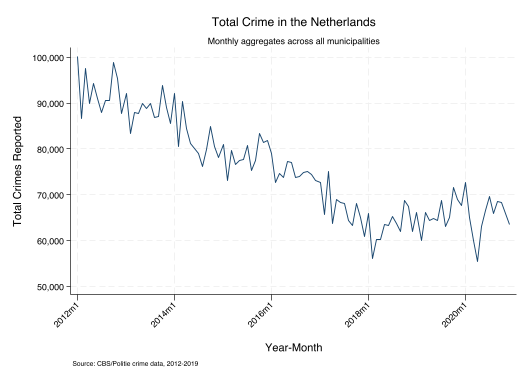

```
✅ National crime time series figure created.
```

### Task 8.2: Overlay Crime and Returns

📝 Task

Create a dual-axis plot showing both crime and stock returns over time. To make them visually comparable, standardize both series (subtract mean, divide by SD). This allows visual inspection of co-movement: when returns are high, is crime higher or lower?

ℹ️ Why Standardize for Visualization?

By standardizing both (z-scores), we can plot them on the same axis and see whether they move together. A standardized value of +1 means "one standard deviation above average" for that series.

If crime and returns move in opposite directions (negative correlation), we should see peaks in one series align with troughs in the other.

```
(Note: Below code run with echo to enable preserve/restore functionality.)

. preserve

. collapse (sum) total_crimes (mean) ret_std_monthly, by(year_month)

. egen mean_crime = mean(total_crimes)

. egen sd_crime = sd(total_crimes)

. gen crime_z = (total_crimes - mean_crime) / sd_crime

. egen mean_ret = mean(ret_std_monthly)

. egen sd_ret = sd(ret_std_monthly)

. gen ret_z = (ret_std_monthly - mean_ret) / sd_ret

. twoway (line crime_z year_month, lcolor(maroon) lwidth(medium) lpattern(solid)) (line ret_z year_month, lcolor(navy) l
> width(medium) lpattern(dash)), title("Crime and Stock Returns Over Time", size(medium)) subtitle("Standardized (z-scor
> es) for visual comparison", size(small)) xtitle("Year-Month") ytitle("Standard Deviations from Mean") xlabel(, angle(4
> 5) labsize(small)) ylabel(, labsize(small)) legend(label(1 "Total Crime (standardized)") label(2 "AEX Returns (standar
> dized)") rows(1) position(6) size(small)) graphregion(color(white)) plotregion(color(white)) yline(0, lcolor(gray) lpa
> ttern(dot)) note("Both series standardized to mean=0, SD=1 for comparability", size(vsmall))

. graph export "$figures/crime_returns_overlay.png", replace width(1200)
file /Users/casparm2/Local/GitHub/MSc_finance/private/assignments/06-assignment/output/figures/crime_returns_overlay.png
>  written in PNG format

. di as txt "---- CHECKPOINT: Crime and returns overlay ----"
---- CHECKPOINT: Crime and returns overlay ----

. di as result "✅ Figure saved: $figures/crime_returns_overlay.png"
✅ Figure saved: /Users/casparm2/Local/GitHub/MSc_finance/private/assignments/06-assignment/output/figures/crime_returns_
> overlay.png

. restore

.
```

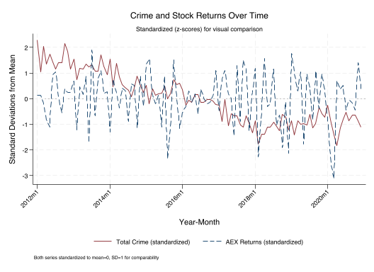

```
✅ Crime and returns overlay figure created.
```

### Task 8.3: Crime Time Series by Income Tercile

📝 Task

Create a plot showing crime trends separately for low, medium, and high-income municipalities. This visualizes the key hypothesis: if Huck's theory holds, crime in high-income areas should move differently than crime in low-income areas when market returns change.

```
(Note: Below code run with echo to enable preserve/restore functionality.)

. preserve

. collapse (sum) total_crimes, by(year_month income_tercile)

. twoway (line total_crimes year_month if income_tercile==1, lcolor(red) lwidth(medium) lpattern(solid)) (line total_cri
> mes year_month if income_tercile==2, lcolor(orange) lwidth(medium) lpattern(dash)) (line total_crimes year_month if in
> come_tercile==3, lcolor(green) lwidth(medium) lpattern(longdash)), title("Crime Trends by Income Tercile", size(medium
> )) subtitle("Total crime aggregated by municipality income group", size(small)) xtitle("Year-Month") ytitle("Total Cri
> mes Reported") xlabel(, angle(45) labsize(small)) ylabel(, labsize(small) format(%12.0fc)) legend(label(1 "Low Income
> (Tercile 1)") label(2 "Medium Income (Tercile 2)") label(3 "High Income (Tercile 3)") rows(1) position(6) size(small))
>  graphregion(color(white)) plotregion(color(white)) note("Source: CBS/Politie crime data by municipality income tercil
> e", size(vsmall))

. graph export "$figures/crime_by_income.png", replace width(1200)
file /Users/casparm2/Local/GitHub/MSc_finance/private/assignments/06-assignment/output/figures/crime_by_income.png writt
> en in PNG format

. di as txt "---- CHECKPOINT: Crime by income tercile ----"
---- CHECKPOINT: Crime by income tercile ----

. di as result "✅ Figure saved: $figures/crime_by_income.png"
✅ Figure saved: /Users/casparm2/Local/GitHub/MSc_finance/private/assignments/06-assignment/output/figures/crime_by_incom
> e.png

. restore

.
```

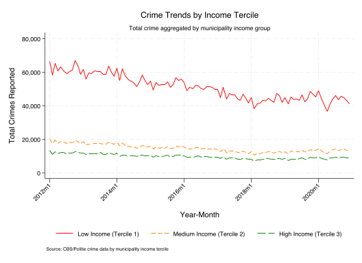

```
✅ Crime by income tercile figure created.
```

🚀 Interpreting the Visualizations

After creating these three plots, examine them carefully:

Figure 1 (National trend): Is crime increasing, decreasing, or stable? Are there seasonal patterns?

Figure 2 (Overlay): Do crime and returns move together (positive correlation) or in opposite directions (negative correlation)? Remember: we expect crime to decrease when returns are high (negative relationship).

Figure 3 (By tercile): Do the three income groups have similar levels and trends? High-income areas typically have lower crime levels. If high-income municipalities have near-zero crime, it may be difficult to detect a relationship with returns (floor effect).

Important: Visual patterns are suggestive but not conclusive. We need regression analysis (next sections) to control for confounders and test statistical significance.

## Section 9: Baseline Panel Regression

We now estimate our first formal statistical tests. The baseline regressions estimate the **average effect** of stock returns on crime across all municipalities, without distinguishing by income group.

**Specification:**

$$\text{Crime}_{it} = \beta_0 + \beta_1 \text{Returns}_t + \alpha_i + \varepsilon_{it}$$

Where:

- $\text{Crime}_{it}$ = Total crimes in municipality $i$ at month $t$
- $\text{Returns}_t$ = Monthly AEX return (compound or standardized)
- $\alpha_i$ = Municipality fixed effects (absorbs time-invariant municipality characteristics)
- $\varepsilon_{it}$ = Error term (clustered at municipality level)

**Key question:** Is $\beta_1$ positive or negative? Does higher return correlate with more or less crime on average?

### Task 9.1: Load Analysis Panel and Verify Structure

📝 Task

Load the analysis panel and verify the panel structure is correctly set. Check that we have the right number of municipalities and time periods before running regressions.

```
Panel variable: muni_id (strongly balanced)
 Time variable: year_month, 2012m1 to 2020m12
         Delta: 1 month

 muni_id:  1, 2, ..., 337                                    n =        337
year_month:  2012m1, 2012m2, ..., 2020m12                    T =        108
           Delta(year_month) = 1 month
           Span(year_month)  = 108 periods
           (muni_id*year_month uniquely identifies each observation)

Distribution of T_i:   min      5%     25%       50%       75%     95%     max
                       108     108     108       108       108     108     108

     Freq.  Percent    Cum. |  Pattern
 ---------------------------+-------------------------------------------------------------------------------------------
> -------------------
      337    100.00  100.00 |  11111111111111111111111111111111111111111111111111111111111111111111111111111111111111111
> 1111111111111111111
 ---------------------------+-------------------------------------------------------------------------------------------
> -------------------
      337    100.00         |  XXXXXXXXXXXXXXXXXXXXXXXXXXXXXXXXXXXXXXXXXXXXXXXXXXXXXXXXXXXXXXXXXXXXXXXXXXXXXXXXXXXXXXXXX
> XXXXXXXXXXXXXXXXXXX
---- CHECKPOINT: Panel structure verified ----
Panel variable: muni_id
Time variable: year_month
Total observations: 36396

Variable      Storage   Display    Value
    name         type    format    label      Variable label
------------------------------------------------------------------------------------------------------------------------
total_crimes    long    %12.0g                Total crimes reported
ret_compound    float   %9.0g                 Monthly compound return
ret_std_monthly float   %9.0g                 Monthly standardized return (sum of daily std ret)
income_tercile  byte    %13.0g     tercile_lbl
                                              Income tercile (1=low, 2=mid, 3=high)
```

```
✅ Panel loaded and structure verified.
```

### Task 9.2: Estimate Baseline with Compound Returns

📝 Task

Estimate the baseline panel regression using compound monthly returns as the independent variable. Use municipality fixed effects and cluster standard errors at the municipality level. Interpret the coefficient: what does it mean economically?

[figure not shown]

Stata Tip: Panel Regression

- `xtreg depvar indepvar, fe` — fixed effects regression
- `vce(cluster muni_id)` — cluster standard errors by municipality
- `estimates store modelname` — save estimates for later comparison
- Coefficient interpretation: A 1 percentage point increase in returns → change of β₁ crimes

```
========================================
Baseline Model: Compound Returns
========================================


Fixed-effects (within) regression               Number of obs     =     36,396
Group variable: muni_id                         Number of groups  =        337

R-squared:                                      Obs per group:
     Within  = 0.0002                                         min =        108
     Between =      .                                         avg =      108.0
     Overall = 0.0000                                         max =        108

                                                F(1, 336)         =      36.31
corr(u_i, Xb) = 0.0000                          Prob > F          =     0.0000

                              (Std. err. adjusted for 337 clusters in muni_id)
------------------------------------------------------------------------------
             |               Robust
total_crimes | Coefficient  std. err.      t    P>|t|     [95% conf. interval]
-------------+----------------------------------------------------------------
ret_compound |   33.71929   5.595892     6.03   0.000     22.71189    44.72668
       _cons |     223.47   .0403306  5540.95   0.000     223.3906    223.5493
-------------+----------------------------------------------------------------
     sigma_u |  562.89334
     sigma_e |  86.074038
         rho |  .97715169   (fraction of variance due to u_i)
------------------------------------------------------------------------------

---- CHECKPOINT: Baseline regression (compound) ----
Coefficient on ret_compound: 33.719288
Standard error: 5.5958915
t-statistic: 6.0257223

Interpretation:
 → Positive coefficient: Higher returns associated with MORE crime
```

```
-------------------------------------------------------
             |           Dependent  Number of
        Name | Command    variable     param.  Title
-------------+-----------------------------------------
 m1_compound | xtreg     total_crimes       2
-------------------------------------------------------
✅ Baseline regression with compound returns estimated.
```

### Task 9.3: Estimate Baseline with Standardized Returns

📝 Task

Estimate the same baseline specification using standardized returns instead of compound returns. This follows Huck (2024)'s methodology more closely. Compare the results: do both return measures give similar findings about the average relationship?

```
========================================
Baseline Model: Standardized Returns
========================================


Fixed-effects (within) regression               Number of obs     =     36,396
Group variable: muni_id                         Number of groups  =        337

R-squared:                                      Obs per group:
     Within  = 0.0010                                         min =        108
     Between =      .                                         avg =      108.0
     Overall = 0.0000                                         max =        108

                                                F(1, 336)         =      43.37
corr(u_i, Xb) = -0.0000                         Prob > F          =     0.0000

                                 (Std. err. adjusted for 337 clusters in muni_id)
---------------------------------------------------------------------------------
                |               Robust
   total_crimes | Coefficient  std. err.      t    P>|t|     [95% conf. interval]
----------------+----------------------------------------------------------------
ret_std_monthly |   .6651736   .1009989     6.59   0.000     .4665037    .8638435
          _cons |   223.2827   .0653305  3417.74   0.000     223.1542    223.4112
----------------+----------------------------------------------------------------
        sigma_u |  562.89334
        sigma_e |  86.039671
            rho |  .97716951   (fraction of variance due to u_i)
---------------------------------------------------------------------------------

---- CHECKPOINT: Baseline regression (standardized) ----
Coefficient on ret_std_monthly: .6651736
Standard error: .10099893
t-statistic: 6.5859472

Interpretation:
 → A 1 SD increase in returns → change of .6651736 crimes
```

```
-------------------------------------------------------
             |           Dependent  Number of
        Name | Command    variable     param.  Title
-------------+-----------------------------------------
 m1_compound | xtreg     total_crimes       2
      m1_std | xtreg     total_crimes       2
-------------------------------------------------------
✅ Baseline regression with standardized returns estimated.
```

ℹ️ Comparing the Two Baseline Models

You have now estimated the same model with two different return measures:

Model 1 (Compound Returns):

Coefficient is in "crimes per 1 percentage point return"

Example: β = -100 means a 1% return reduces crime by 100 incidents

Easy to interpret economically (percentage points are intuitive)

Model 2 (Standardized Returns):

Coefficient is in "crimes per 1 standard deviation return"

Example: β = -50 means a 1 SD return surprise reduces crime by 50 incidents

Captures the "surprise" interpretation (Huck's methodology)

Controls for volatility regime changes

What to expect: Both should show the same sign (positive or negative) but different magnitudes. The standardized version is preferred for comparability to Huck (2024).

Important limitation: These baseline models estimate the average effect across all income groups. They do not test Huck's key hypothesis about differential effects. That comes in Section 10.

## Section 10: Differential Effects by Income (Core Test)

This is the **key test** of Huck's hypothesis: Do stock returns affect crime **differently** in high-income vs. low-income areas?

**Huck's (2024) finding:**

- **High-income areas** (investors): Returns ↑ → Crime ↓ (negative coefficient)
- **Low-income areas** (non-investors): Returns ↑ → Crime ↑ (positive coefficient)

**Mechanism:** Relative wealth/status affects psychological well-being. When the market rises:

- Investors feel wealthier → better mood → less crime
- Non-investors feel relatively poorer → worse mood → more crime

**Our specification (with interactions):**

$$\text{Crime}_{it} = \beta_0 + \beta_1 \text{Returns}_t + \beta_2 (\text{Returns}_t \times \text{High}_{i}) + \beta_3 (\text{Returns}_t \times \text{Low}_{i}) + \alpha_i + \varepsilon_{it}$$

Where:

- $\beta_1$ = Effect in medium-income areas (reference group)
- $\beta_1 + \beta_2$ = Effect in high-income areas
- $\beta_1 + \beta_3$ = Effect in low-income areas

**Key test:** Is $\beta_2 < 0$ (high-income negative) and $\beta_3 > 0$ (low-income positive)?

### Task 10.1: Estimate Interactions with Compound Returns

📝 Task

Create interaction terms between compound returns and income tercile dummies, then estimate the model. The interactions allow the effect of returns to differ across high, medium, and low-income municipalities.

[figure not shown]

Stata Tip: Interaction Terms

- `gen ret_comp_high = ret_compound * high_income` — interaction with high tercile
- `gen ret_comp_low = ret_compound * low_income` — interaction with low tercile
- Include base return + both interactions in regression
- Mid-income is the reference group (omitted interaction)

```
========================================
Interaction Model: Compound Returns
========================================


Fixed-effects (within) regression               Number of obs     =     36,396
Group variable: muni_id                         Number of groups  =        337

R-squared:                                      Obs per group:
     Within  = 0.0003                                         min =        108
     Between = 0.0773                                         avg =      108.0
     Overall = 0.0005                                         max =        108

                                                F(3, 336)         =      30.46
corr(u_i, Xb) = 0.0206                          Prob > F          =     0.0000

                               (Std. err. adjusted for 337 clusters in muni_id)
-------------------------------------------------------------------------------
              |               Robust
 total_crimes | Coefficient  std. err.      t    P>|t|     [95% conf. interval]
--------------+----------------------------------------------------------------
 ret_compound |   30.98816   4.947572     6.26   0.000     21.25604    40.72028
ret_comp_high |  -14.13262   5.612347    -2.52   0.012    -25.17238   -3.092854
 ret_comp_low |    22.1526   16.31395     1.36   0.175    -9.937742    54.24294
        _cons |     223.47   .0399011  5600.59   0.000     223.3915    223.5485
--------------+----------------------------------------------------------------
      sigma_u |  562.86335
      sigma_e |  86.074397
          rho |  .97714912   (fraction of variance due to u_i)
-------------------------------------------------------------------------------

---- CHECKPOINT: Interaction model (compound) ----

Effect in medium-income areas (reference): 30.988159
Additional effect in high-income areas: -14.132618
Additional effect in low-income areas: 22.152601

Total effect by income group:
 Low-income: 53.14076
 Mid-income: 30.988159
 High-income: 16.855541
```

```
-------------------------------------------------------
             |           Dependent  Number of
        Name | Command    variable     param.  Title
-------------+-----------------------------------------
 m1_compound | xtreg     total_crimes       2
      m1_std | xtreg     total_crimes       2
 m2_compound | xtreg     total_crimes       4
-------------------------------------------------------
✅ Interaction model with compound returns estimated.
```

### Task 10.2: Estimate Interactions with Standardized Returns

📝 Task

Estimate the same interaction model using standardized returns. The interaction terms `ret_x_high`, `ret_x_mid`, and `ret_x_low` were already created in Part A (Section 6). This specification follows Huck (2024)'s methodology exactly.

```
Variable      Storage   Display    Value
    name         type    format    label      Variable label
------------------------------------------------------------------------------------------------------------------------
ret_x_high      float   %9.0g                 Standardized return × High income
ret_x_mid       float   %9.0g                 Standardized return × Medium income
ret_x_low       float   %9.0g                 Standardized return × Low income

========================================
Interaction Model: Standardized Returns
========================================


Fixed-effects (within) regression               Number of obs     =     36,396
Group variable: muni_id                         Number of groups  =        337

R-squared:                                      Obs per group:
     Within  = 0.0015                                         min =        108
     Between = 0.0835                                         avg =      108.0
     Overall = 0.0010                                         max =        108

                                                F(3, 336)         =      55.37
corr(u_i, Xb) = 0.0256                          Prob > F          =     0.0000

                              (Std. err. adjusted for 337 clusters in muni_id)
------------------------------------------------------------------------------
             |               Robust
total_crimes | Coefficient  std. err.      t    P>|t|     [95% conf. interval]
-------------+----------------------------------------------------------------
   ret_x_low |    1.30699   .2843909     4.60   0.000     .7475796    1.866401
   ret_x_mid |   .4399819   .0600953     7.32   0.000     .3217714    .5581924
  ret_x_high |   .2428179   .0254009     9.56   0.000     .1928532    .2927826
       _cons |   223.2827   .0632572  3529.76   0.000     223.1583    223.4072
-------------+----------------------------------------------------------------
     sigma_u |  562.80676
     sigma_e |   86.02041
         rho |  .97717264   (fraction of variance due to u_i)
------------------------------------------------------------------------------

---- CHECKPOINT: Interaction model (standardized) ----

Effect by income group (per 1 SD return):
 Low-income: 1.3069905
 Mid-income: .43998192
 High-income: .24281791

✗ Both positive: Returns increase crime in all groups
```

### Task 10.3: Interpret the Differential Effects

📝 Task

Compare the estimated coefficients across income groups and answer the following questions in the markdown cell below:

1. Are the coefficients for high-income and low-income areas statistically significant?
2. What are the signs of the coefficients? Do they match Huck's findings?
3. What is the economic magnitude? (How many crimes per SD of return?)
4. Why might the pattern differ from Huck's US findings?

**Your interpretation here:**

*(Write your answer below. Minimum 150 words.)*

1. **Statistical significance:**

ℹ️ Interpreting Interaction Coefficients

**What Huck (2024) found in the US:**  
Using daily data from 2,700 police agencies (1991-2015):

- **High-income areas (investors):** A 1 SD return increase → **37 bps decrease** in violent crime (−12.5 crimes per 100M population)
- **Low-income areas (noninvestors):** A 1 SD return increase → **25 bps increase** in violent crime (+15.2 crimes per 100M population)
- The difference between high and low income coefficients is statistically significant (t = 3.31)

What you should look for:

Sign: Is high-income negative and low-income positive?

Significance: Are t-statistics > 2 (roughly 5% significance)?

Magnitude: Are effects economically meaningful?

Difference: Is the high-low gap statistically significant?

Why results might differ:

Monthly vs daily data (timing mechanism lost)

Different country context (NL vs US investor participation rates)

Income terciles are imperfect proxy for investor status

Different crime types/reporting systems

## Section 11: Two-Way Fixed Effects

So far we have used **one-way fixed effects** (municipality FE only). This controls for time-invariant municipality characteristics (e.g., urban vs rural, demographics) but does not control for **time shocks** that affect all municipalities simultaneously.

**Two-way fixed effects (TWFE)** adds **time fixed effects** to absorb common shocks:

$$\text{Crime}_{it} = \beta_2 (\text{Returns}_t \times \text{High}_{i}) + \beta_3 (\text{Returns}_t \times \text{Low}_{i}) + \alpha_i + \gamma_t + \varepsilon_{it}$$

Where:

- $\alpha_i$ = Municipality fixed effects
- $\gamma_t$ = Time (year-month) fixed effects
- **Note:** The main return effect $\beta_1 \text{Returns}_t$ is **absorbed** by time FE because all municipalities have the same return in month $t$

**What time FE controls for:**

- Seasonal crime patterns (more crime in summer?)
- National policy changes (new policing strategies)
- Economic conditions (unemployment, GDP growth)
- Any factor that affects all municipalities equally in a given month

**Key advantage:** Better identification of differential effects across income groups by removing confounding time trends.

### Task 11.1: Estimate TWFE with reghdfe

📝 Task

Estimate the interaction model with two-way fixed effects using `reghdfe`. This package efficiently handles high-dimensional fixed effects (many municipalities × many months). Include only the interaction terms, as the main return effect is absorbed by time FE.

[figure not shown]

Stata Tip: reghdfe

- `reghdfe depvar indepvars, absorb(fe1 fe2) vce(cluster var)`
- `absorb(muni_id year_month)` — absorbs both municipality and time FE
- Do NOT include main return effect (it's collinear with time FE)
- Only include interactions that vary within time periods (income × returns)

```
========================================
Two-Way Fixed Effects Model
========================================

Note: Main return effect absorbed by time FE
 (all municipalities have same return each month)

(MWFE estimator converged in 2 iterations)

HDFE Linear regression                            Number of obs   =     36,396
Absorbing 2 HDFE groups                           F(   2,    336) =      11.10
Statistics robust to heteroskedasticity           Prob > F        =     0.0000
                                                  R-squared       =     0.9805
                                                  Adj R-squared   =     0.9802
                                                  Within R-sq.    =     0.0006
Number of clusters (muni_id) =        337         Root MSE        =    79.9471

                              (Std. err. adjusted for 337 clusters in muni_id)
------------------------------------------------------------------------------
             |               Robust
total_crimes | Coefficient  std. err.      t    P>|t|     [95% conf. interval]
-------------+----------------------------------------------------------------
  ret_x_high |   -.197164   .0653383    -3.02   0.003    -.3256876   -.0686404
   ret_x_low |   .8670085   .2910952     2.98   0.003     .2944098    1.439607
       _cons |   223.5673   .0672407  3324.88   0.000     223.4351    223.6996
------------------------------------------------------------------------------

Absorbed degrees of freedom:
-----------------------------------------------------+
 Absorbed FE | Categories  - Redundant  = Num. Coefs |
-------------+---------------------------------------|
     muni_id |       337         337           0    *|
  year_month |       108           1         107     |
-----------------------------------------------------+
* = FE nested within cluster; treated as redundant for DoF computation

---- CHECKPOINT: Two-way FE model ----

Effect by income group (relative to mid-income):
 High-income: -.19716402
 Low-income: .86700855

Fixed effects absorbed:
 Municipalities: .
 Time periods: .
```

```
---------------------------------------------------------------------
             |           Dependent  Number of
        Name | Command    variable     param.  Title
-------------+-------------------------------------------------------
 m1_compound | xtreg     total_crimes       2
      m1_std | xtreg     total_crimes       2
 m2_compound | xtreg     total_crimes       4
      m2_std | xtreg     total_crimes       4
     m3_twfe | reghdfe   total_crimes       3  HDFE Linear regression
---------------------------------------------------------------------
✅ Two-way fixed effects model estimated.
```

### Task 11.2: Compare One-Way vs Two-Way Fixed Effects

📝 Task

Display the results side-by-side to compare how coefficients change when adding time fixed effects. Use `esttab` to create a clean comparison table showing both specifications.

```
========================================
Comparison: One-Way FE vs Two-Way FE
========================================


Effect of Standardized Returns on Crime by Income Group
----------------------------------------------------
                              (1)             (2)
                       One-Way FE      Two-Way FE
----------------------------------------------------
Monthly standardiz~m


Standardized retur~e        1.307***        0.867***
                          (0.284)         (0.291)

Standardized retur~c        0.440***
                          (0.060)

Standardized retur~m        0.243***       -0.197***
                          (0.025)         (0.065)
----------------------------------------------------
Observations               36,396          36,396
Adjusted R²                 0.001           0.980
----------------------------------------------------
Standard errors in parentheses
* p<0.10, ** p<0.05, *** p<0.01

---- CHECKPOINT: Model comparison ----

Key differences:
 • One-Way FE: Controls for municipality characteristics only
 • Two-Way FE: Controls for municipality + time shocks

Questions to consider:
 1. Do coefficients change substantially?
 2. Do significance levels change?
 3. Which specification is more credible?
```

```
---------------------------------------------------------------------
             |           Dependent  Number of
        Name | Command    variable     param.  Title
-------------+-------------------------------------------------------
 m1_compound | xtreg     total_crimes       2
      m1_std | xtreg     total_crimes       2
 m2_compound | xtreg     total_crimes       4
      m2_std | xtreg     total_crimes       4
     m3_twfe | reghdfe   total_crimes       3  HDFE Linear regression
---------------------------------------------------------------------
✅ Model comparison displayed.
```

ℹ️ Why Two-Way Fixed Effects?

**What changes with TWFE:**

- **Identification:** Effects now identified purely from differential responses across income groups (within-month variation)
- **Confounders removed:** Any national trend (seasonality, policy changes, economic conditions) is absorbed
- **Main effect absorbed:** Cannot estimate average return effect (all municipalities have same return each month)

How to interpret coefficient changes:

Coefficients shrink: One-way FE had omitted variable bias from time trends

Coefficients grow: Time FE removed noise, revealing stronger differential effects

Signs flip: Confounding was severe (unusual but possible)

No change: Time trends were uncorrelated with treatment (rare)

Which is more credible?  
Two-way FE is generally preferred because:

Controls for more confounders

Standard in modern applied work (Angrist & Pischke, Cunningham)

Necessary when there are common time shocks (which there always are)

However, TWFE has limitations:

Cannot estimate main treatment effect

If treatment varies over time AND across units, identification comes solely from differential time trends

## Section 12: Robustness Checks

Good empirical work tests whether findings are **robust** to alternative specifications. If results change dramatically across reasonable alternatives, they may be fragile or driven by specific modeling choices.

We test three alternative specifications:

1. **Log specification** — Test whether effects are proportional (% changes) rather than absolute
2. **Assault crimes only** — Focus on violent crime (closer to Huck's dependent variable)
3. **Volatility instead of returns** — Test whether market uncertainty (not direction) affects crime

**What makes a good robustness check?**

- Addresses a legitimate alternative hypothesis
- Changes one thing at a time (outcome, specification, or sample)
- Has a clear interpretation if results differ

All robustness checks use the **TWFE specification** (municipality + time FE) from Section 11.

### Task 12.1: Log Specification

📝 Task

Re-estimate the TWFE model using log-transformed crime as the dependent variable. This tests whether returns affect crime in **percentage terms** rather than absolute counts. Create the log variable if it doesn't exist, then estimate the model.

ℹ️ Why Log Specification?

**Levels vs Logs:**

- **Levels:** β measures change in crime *counts* (e.g., 10 more crimes)
- **Logs:** β measures change in *percentage* (e.g., 2% increase)

When logs are preferred:

Effects are proportional to baseline (bigger cities have bigger absolute changes)

Outcome is skewed (few very high-crime municipalities)

Interpretation in % is more natural

Technical note: We use ln(crime + 1) to handle zeros (some municipalities have zero assault/murder in some months).

```
========================================
Robustness Check 1: Log Specification
========================================

(MWFE estimator converged in 2 iterations)

HDFE Linear regression                            Number of obs   =     36,396
Absorbing 2 HDFE groups                           F(   2,    336) =       0.54
Statistics robust to heteroskedasticity           Prob > F        =     0.5830
                                                  R-squared       =     0.9676
                                                  Adj R-squared   =     0.9672
                                                  Within R-sq.    =     0.0000
Number of clusters (muni_id) =        337         Root MSE        =     0.1909

                              (Std. err. adjusted for 337 clusters in muni_id)
------------------------------------------------------------------------------
             |               Robust
log_total_~s | Coefficient  std. err.      t    P>|t|     [95% conf. interval]
-------------+----------------------------------------------------------------
  ret_x_high |   .0001186   .0005546     0.21   0.831    -.0009723    .0012095
   ret_x_low |  -.0003916   .0004915    -0.80   0.426    -.0013584    .0005752
       _cons |   4.680233   .0001938  2.4e+04   0.000     4.679852    4.680615
------------------------------------------------------------------------------

Absorbed degrees of freedom:
-----------------------------------------------------+
 Absorbed FE | Categories  - Redundant  = Num. Coefs |
-------------+---------------------------------------|
     muni_id |       337         337           0    *|
  year_month |       108           1         107     |
-----------------------------------------------------+
* = FE nested within cluster; treated as redundant for DoF computation

---- CHECKPOINT: Log specification ----

Interpretation:
 Coefficients now measure % changes in crime
 High-income: 0.0001 (1 SD return →   0.01% change)
 Low-income: -0.0004 (1 SD return →  -0.04% change)
```

```
---------------------------------------------------------------------
             |           Dependent  Number of
        Name | Command    variable     param.  Title
-------------+-------------------------------------------------------
 m1_compound | xtreg     total_crimes       2
      m1_std | xtreg     total_crimes       2
 m2_compound | xtreg     total_crimes       4
      m2_std | xtreg     total_crimes       4
     m3_twfe | reghdfe   total_crimes       3  HDFE Linear regression
      m4_log | reghdfe   log_total_~s       3  HDFE Linear regression
---------------------------------------------------------------------
✅ Log specification estimated.
```

### Task 12.2: Assault Crimes Only

📝 Task

Test whether the differential effects hold when focusing on **assault crimes only**. Huck (2024) examines violent crime, and assault is the closest measure we have in the Netherlands data. This tests whether the psychological mechanism primarily affects violent vs property crime.

[output not shown]

```
---------------------------------------------------------------------
             |           Dependent  Number of
        Name | Command    variable     param.  Title
-------------+-------------------------------------------------------
 m1_compound | xtreg     total_crimes       2
      m1_std | xtreg     total_crimes       2
 m2_compound | xtreg     total_crimes       4
      m2_std | xtreg     total_crimes       4
     m3_twfe | reghdfe   total_crimes       3  HDFE Linear regression
      m4_log | reghdfe   log_total_~s       3  HDFE Linear regression
  m5_assault | reghdfe   assault_cr~s       3  HDFE Linear regression
---------------------------------------------------------------------
✅ Assault crimes specification estimated.
```

### Task 12.3: Volatility Instead of Returns

📝 Task

Test an alternative mechanism: Does market **uncertainty** (volatility) affect crime, regardless of return direction? Create interaction terms between volatility and income terciles, then estimate the model. This tests whether psychological effects come from uncertainty rather than wealth changes.

ℹ️ Returns vs Volatility

**Two psychological channels:**

- **Returns (direction):** Investors feel richer when market rises → better mood → less crime
- **Volatility (uncertainty):** Market turbulence creates stress/anxiety → worse mood → more crime

Expected pattern if volatility matters:  
Higher volatility → more crime in high-income areas (investors stressed by uncertainty)

Variable used: volatility = within-month SD of daily returns (calculated in Section 3)

[output not shown]

```
---------------------------------------------------------------------
             |           Dependent  Number of
        Name | Command    variable     param.  Title
-------------+-------------------------------------------------------
 m1_compound | xtreg     total_crimes       2
      m1_std | xtreg     total_crimes       2
 m2_compound | xtreg     total_crimes       4
      m2_std | xtreg     total_crimes       4
     m3_twfe | reghdfe   total_crimes       3  HDFE Linear regression
      m4_log | reghdfe   log_total_~s       3  HDFE Linear regression
  m5_assault | reghdfe   assault_cr~s       3  HDFE Linear regression
m6_volatil~y | reghdfe   total_crimes       3  HDFE Linear regression
---------------------------------------------------------------------
✅ Volatility specification estimated.
```

🚀 Interpreting Robustness Checks

**What to conclude from robustness checks:**

If results are similar across specifications:  
→ Findings are robust; not driven by specific modeling choices  
→ Confidence in main result increases

If results differ substantially:  
→ Effects may be heterogeneous (e.g., only for violent crime)  
→ Or main specification had issues (e.g., skewed outcome needed logs)  
→ Discuss why differences arise and which specification is preferred

If volatility matters more than returns:  
→ Uncertainty/stress channel dominates wealth effect  
→ Challenges Huck's specific mechanism

Common practice: Present main result (TWFE with levels) in text, show robustness in appendix table. If robustness checks reveal important heterogeneity, discuss in main text.

## Section 13: Regression Table

We now create a **publication-quality regression table** combining all our main results. This table summarizes the entire empirical analysis in a format suitable for a thesis or research paper.

**Good regression tables should:**

1. Show coefficients with standard errors (in parentheses)
2. Use stars to indicate significance levels (*** p<0.01, ** p<0.05, * p<0.10)
3. Report key model statistics (N, R², fixed effects)
4. Have clear column headers describing each specification
5. Be formatted for easy comparison across models

We will create a table with the following models:

- **Column 1:** Baseline (standardized returns, one-way FE)
- **Column 2:** Interactions (standardized returns, one-way FE)
- **Column 3:** TWFE (standardized returns, municipality + time FE)
- **Column 4:** Log specification (TWFE)
- **Column 5:** Assault crimes (TWFE)

This table will be exported as LaTeX for inclusion in reports.

### Task 13.1: Create Publication-Quality Regression Table

📝 Task

Use `esttab` to combine all stored estimates into a professional table. Export to both screen display (for review) and LaTeX format (for thesis). Include coefficient estimates, standard errors, significance stars, and model statistics.

[figure not shown]

Stata Tip: Creating Professional Tables with esttab

Key options for `esttab`:

- `se(3)` — show standard errors with 3 decimals
- `star(* 0.10 ** 0.05 *** 0.01)` — significance stars
- `mtitles("Model 1" "Model 2" ...)` — column headers
- `keep(varlist)` — which variables to show
- `order(varlist)` — row order
- `stats(N r2_a, labels("Observations" "Adjusted R²"))` — model statistics
- `label` — use variable labels instead of names

```
========================================
Main Regression Results Table
========================================


Table 1: Effect of Stock Returns on Crime by Income Group
----------------------------------------------------------------------------------------------------
                         Baseline    Interactions            TWFE             Log         Assault
----------------------------------------------------------------------------------------------------
Monthly standardiz~m        0.665***
                          (0.101)

Standardized retur~e                        1.307***        0.867***    -0.000392          0.0263
                                          (0.284)         (0.291)         (0.000)         (0.017)

Standardized retur~c                        0.440***
                                          (0.060)

Standardized retur~m                        0.243***       -0.197***     0.000119       -0.000985
                                          (0.025)         (0.065)         (0.001)         (0.007)
----------------------------------------------------------------------------------------------------
Observations               36,396          36,396          36,396          36,396          36,396
Adjusted R²                 0.001           0.001           0.980           0.967           0.967
----------------------------------------------------------------------------------------------------
Standard errors in parentheses
* p<0.10, ** p<0.05, *** p<0.01

Notes for table:
 • Dependent variable: Total crimes (Columns 1-3), Log(total crimes) (Column 4), Assault crimes (Column 5)
 • All models include municipality fixed effects
 • Columns 3-5 include time (year-month) fixed effects
 • Standard errors clustered at municipality level in parentheses
 • * p<0.10, ** p<0.05, *** p<0.01
(output written to /Users/casparm2/Local/GitHub/MSc_finance/private/assignments/06-assignment/output/tables/main_results
> .tex)

---- CHECKPOINT: Regression table created ----
✅ Table exported to: /Users/casparm2/Local/GitHub/MSc_finance/private/assignments/06-assignment/output/tables/main_resul
> ts.tex
 Models included: 5 (Baseline through Assault)
```

```
✅ Main regression table exported successfully.
```

🚀 Above and Beyond: Volatility Results Table

The volatility specification (m6) tests a different mechanism and uses different independent variables. It shouldn't be in the main table but could go in an appendix or supplementary table.

If you want to create a separate volatility table, use:  
esttab m6_volatility using "$tables/volatility_results.tex"

This keeps your main results table clean and focused on the return → crime relationship.

ℹ️ Reading the Table

**How to interpret the table:**

Column progression (left to right):

Baseline: Average effect of returns (no income differences)

Interactions: Effects by income group (key test!)

TWFE: Same as (2) but with time FE (preferred specification)

Log: Percentage changes instead of levels

Assault: Violent crime only

What to look for:

Consistency across columns 2-5: Do interaction coefficients have same signs?

Statistical significance: How many stars (*** = strong, ** = moderate, * = weak)?

Economic magnitude: Are effects large enough to matter?

R² changes: Does adding interactions improve fit?

For your thesis: This table would go in the main body. The volatility table (if created) would go in an appendix. Always accompany tables with 2-3 paragraphs of interpretation in text.

## Section 14: Interpretation and Limitations

The empirical analysis is complete. Now we interpret the findings and honestly discuss limitations.

**Good empirical papers have three key elements:**

1. **Clear interpretation** of what the results mean economically and statistically
2. **Honest discussion** of limitations (what the study cannot test or conclude)
3. **Constructive suggestions** for how future work could improve identification

**Why limitations matter:**

- Prevents over-claiming (saying more than the data can support)
- Shows you understand the research design deeply
- Guides readers on how to interpret your findings
- In your thesis, examiners expect thoughtful discussion of what you **cannot** claim

This section has three writing tasks that synthesize everything you've learned.

### Task 14.1: Summarize Your Findings

📝 Task

Write a summary of your main findings (minimum 200 words). Address the following questions:

1. **Main result:** Do you find differential effects of returns across income groups?
2. **Signs:** Are the signs consistent with Huck (2024)'s theory? (High negative, low positive?)
3. **Statistical significance:** Are the key coefficients statistically significant?
4. **Economic magnitude:** How large are the effects? (e.g., "A 1 SD positive return reduces crime by X incidents in high-income areas")
5. **Robustness:** Do results hold across specifications (TWFE, log, assault)?
6. **Comparison to Huck:** Are your findings consistent with or different from the US results?

**Your findings summary (minimum 200 words):**

*(Write your answer below)*

### Task 14.2: Discuss Limitations

📝 Task

Discuss at least **three substantive limitations** of this analysis (minimum 150 words). For each limitation:

- Explain what the limitation is
- Why it matters (what it prevents you from concluding)
- How it differs from the original Huck (2024) study

Suggested limitations to consider:

Monthly vs daily frequency: Cannot test contemporaneous/hourly timing effects

Single market return: No cross-sectional variation in "treatment" within months

Income as proxy: Municipality income ≠ individual investor status (ecological fallacy)

Standard error concerns: Few time periods, spatial correlation across municipalities

Crime reporting differences: Measurement error varies by municipality/crime type

Selection/attrition: Municipality boundaries changed over time (mergers)

⚠️ Important: Be Honest

Good researchers are **honest about limitations**. This doesn't weaken your work—it shows you understand the research design deeply.

What NOT to do:

❌ "We don't have enough data" (too vague)

❌ "Results might be wrong" (undermines everything)

❌ List minor issues without explaining why they matter

What TO do:

✓ "Monthly data cannot test within-day timing effects (Huck's Table 5), limiting our ability to distinguish same-day from lagged effects"

✓ "Municipality-level income is an imperfect proxy for investor participation; Huck uses actual brokerage data, providing more precise treatment assignment"

✓ Explain the consequence of each limitation

**Your limitations discussion (minimum 150 words, at least 3 points):**

*(Write your answer below)*

**Limitation 1:**

**Limitation 2:**

**Limitation 3:**

### Task 14.3: What Would Strengthen This Analysis?

📝 Task

Suggest at least **three improvements** that would strengthen the identification or generalizability of this analysis (minimum 100 words). Think creatively about:

- **Better data:** What data would you ideally have?
- **Natural experiments:** Are there shocks you could exploit for causal identification?
- **Alternative mechanisms:** What else could you test?
- **Extensions:** How could you expand this to related questions?

Examples to consider:

Daily crime data (if it existed in NL)

Individual investor data (brokerage accounts by municipality)

Natural experiment: Neo-broker entry (Trade Republic, DEGIRO expansion) for DiD

Cross-country comparison (UK has better crime data?)

Alternative outcomes: Health, well-being, Google searches

Crypto markets (more volatile, younger investors)

**Your suggestions for improvement (minimum 100 words, at least 3 ideas):**

*(Write your answer below)*

**Improvement 1:**

**Improvement 2:**

**Improvement 3:**

## Part B Summary

**Congratulations!** You have completed Part B: Analysis.

**What you accomplished:**

1. ✅ **Section 7**: Created descriptive statistics by income tercile
2. ✅ **Section 8**: Visualized crime and return trends over time
3. ✅ **Section 9**: Estimated baseline panel regressions
4. ✅ **Section 10**: Tested differential effects by income (core hypothesis)
5. ✅ **Section 11**: Added two-way fixed effects for better identification
6. ✅ **Section 12**: Conducted robustness checks (log, assault, volatility)
7. ✅ **Section 13**: Created publication-quality regression table
8. ✅ **Section 14**: Interpreted findings and discussed limitations honestly

**Outputs created:**

**Skills practiced:**

- Panel data regression with fixed effects
- Testing interaction effects
- Two-way fixed effects estimation
- Robustness checks
- Creating professional tables and figures
- Interpreting results and discussing limitations

**Your thesis Module 2/3 will look very similar:**

- Part A (Data Preparation): 60-70% of your time
- Part B (Analysis): 20-30% of your time
- Part C (Writing/Interpretation): 10% of your time

The skills you practiced here—data wrangling, regression analysis, robustness checks, honest limitation discussion—are exactly what you'll need for your MSc thesis.

# Part C: Thesis Connection and Reflection

This final section connects your work to the MSc thesis and reflects on what you've learned.

## Section 15: Thesis Module 2/3 Connection

Your MSc Finance thesis has three modules:

- **Module 1:** Literature review and research question
- **Module 2:** Replication of published results with new/similar data
- **Module 3:** Extension or new analysis building on Module 2

This assignment mirrors the **Module 2/3 workflow**. You've essentially completed a mini-thesis:

- Read a published paper (Huck 2024)
- Replicated the methodology with new data (Netherlands instead of US)
- Tested whether findings generalize to a new setting

The questions below help you think about how this experience prepares you for your actual thesis.

### Task 15.1: How Does This Relate to Your Thesis?

📝 Reflection Task

Reflect on how this assignment relates to your thesis work (minimum 150 words). Consider:

- **Module 2 (Replication):** What did you learn about replicating published results? What challenges did you face?
- **Module 3 (Extension):** If you were to extend this analysis for a thesis, what would you do differently? What extension would be most interesting?
- **Data preparation:** How much time did Part A (data prep) take compared to Part B (analysis)? Is this ratio surprising?
- **Skills:** Which skills from this assignment will be most useful for your thesis?

**Your reflection on thesis connection (minimum 150 words):**

*(Write your answer below)*

### Task 15.2: What Would a "Full" Replication Require?

📝 Reflection Task

Describe what a "full" replication of Huck (2024) would require (minimum 100 words). Think about:

- **Data:** What exact data would you need?
- **Frequency:** Why does daily vs monthly matter for Huck's mechanism?
- **Treatment measurement:** How did Huck measure investor status? How is that different from our income terciles?
- **Fixed effects:** What fixed effects structure did Huck use?
- **Feasibility:** Is a full replication feasible with available Netherlands data?

**What a full replication would require (minimum 100 words):**

*(Write your answer below)*

### Task 15.3: Extension Ideas for a Thesis

📝 Reflection Task

Propose at least **two extension ideas** that could make a viable MSc thesis (minimum 100 words). For each idea, briefly describe:

- The research question
- What data you would need
- Why it would be an interesting contribution

Example extension ideas:

DiD with neo-broker entry: Trade Republic/DEGIRO expansion created differential investor access across municipalities → DiD design

Crypto markets: Higher volatility, younger investors → test whether effects are stronger for crypto than stocks

Alternative outcomes: Health visits, mental health claims, Google searches for stress-related terms

Cross-country: Compare NL, Belgium, Germany using harmonized data

Mechanism test: Does effect vary by crime type (impulsive vs planned)?

**Your extension ideas (minimum 100 words, at least 2 ideas):**

*(Write your answer below)*

**Extension Idea 1:**

**Extension Idea 2:**

## Section 16: Conclusion

You have completed a full replication/extension exercise from start to finish.

**What you accomplished:**

**Part A (Data Preparation):**

- Loaded and examined three raw datasets
- Calculated monthly returns following published methodology
- Reshaped data from long to wide format
- Merged multiple datasets into a panel
- Created analysis variables (terciles, interactions)

**Part B (Analysis):**

- Created descriptive statistics and visualizations
- Estimated baseline and interaction regressions
- Tested differential effects across income groups (Huck's hypothesis)
- Added two-way fixed effects for better identification
- Conducted robustness checks
- Created publication-quality tables
- Interpreted results and discussed limitations honestly

**Part C (Reflection):**

- Connected the analysis to your MSc thesis
- Understood the gap between ideal replication and feasible tests
- Proposed creative extensions for future work

**Key lessons:**

1. **Data preparation is 60-80% of empirical work** — You spent most time in Part A, not Part B. This is normal and expected.
2. **Published papers use better data than you'll have** — Huck has daily crime data and actual investor accounts. You have monthly aggregates and income proxies. This is the reality of replication work.
3. **Honest limitation discussion is a strength** — Acknowledging what you cannot test shows deep understanding of research design.
4. **Even null results are informative** — If you don't find Huck's pattern in NL data, that's a contribution (generalizability is limited).
5. **Extensions matter more than perfect replication** — Your thesis should test something new, even if it's a simple extension.

**For your MSc thesis:**

- Choose a paper with **accessible data** (not proprietary)
- Start data preparation **early** (it always takes longer than expected)
- Be **realistic** about what you can test with available data
- Focus on a **simple, clear extension** rather than perfect replication
- Discuss limitations **honestly** (examiners value this highly)

**Final thought:**

Research is about answering questions with imperfect data and honest acknowledgment of limitations. You've practiced exactly that in this assignment. These skills—data wrangling, regression analysis, robustness testing, limitation discussion—will serve you well in your thesis and beyond.

Good luck with your MSc thesis! 🎓

Data Analytics for Finance

BM17FI · Academic Year 2025–26

Created by: Caspar David Peter

© 2026 Rotterdam School of Management